# Задача_1

### Оценка точности модели с непрерывной зависимой переменной

В данной задаче выполняются следующие пункты:

- разделение данных на выборки (обучающая и тестовая);
- расчет MSE (среднеквадратическая ошибка модели);
- анализ изменения MSE на тестовой и обучающей выборках с изменением гибкости (числа степеней свободы) модели.

*Модели*: сглаживающие сплайны.  
*Данные*: сгенерированные.

Сгенерируем $X$ и $Y$:

- $X \sim U(5, 105)$
- $Y = f(X) + \epsilon$, где $f(X) = 12 - 0.05X$; $\epsilon \sim N(0, 1)$.

## 1. Генерация данных.

```r
my.seed <- 1486372882    # ядро
n.all <- 60              # наблюдений всего
train.percent <- 0.85    # доля обучающей выборки
res.sd <- 1              # стандартное отклонение случайного шума
x.min <- 5               # границы изменения X: нижняя
x.max <- 105             #  и верхняя

# фактические значения x
set.seed(my.seed)
x <- runif(x.min, x.max, n = n.all)

# случайный шум
set.seed(my.seed)
res <- rnorm(mean = 0, sd = res.sd, n = n.all)

# отбираем наблюдения в обучающую выборку
set.seed(my.seed)
inTrain <- sample(seq_along(x), size = train.percent*n.all)

# истинная функция взаимосвязи
y.func <- function(x) {12 - 0.05 * x}

# для графика истинной взаимосвязи
x.line <- seq(x.min, x.max, length = n.all)
y.line <- y.func(x.line)

# фактические значения y (с шумом)
y <- y.func(x) + res

# Создаём векторы с данными для построения графиков ############################

# наблюдения на обучающей выборке
x.train <- x[inTrain]
y.train <- y[inTrain]

# наблюдения на тестовой выборке
x.test <- x[-inTrain]
y.test <- y[-inTrain]
```

## 2. Отображение исходных данных на графике.

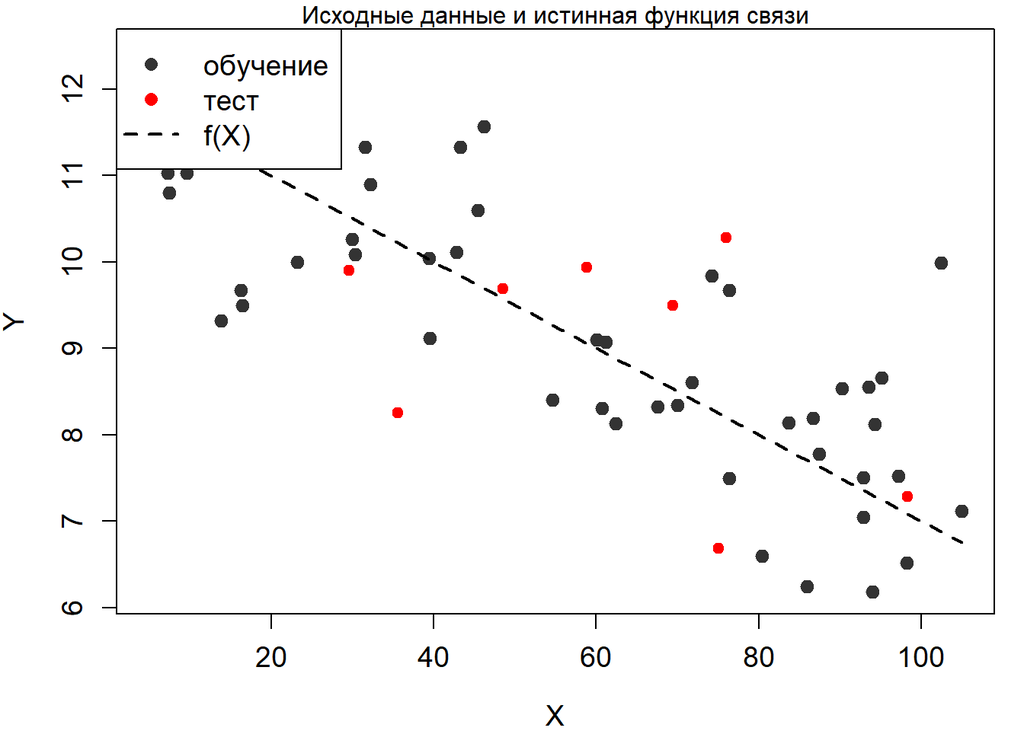

```r
#  График 1: Исходные данные на график #########################################

# убираем широкие поля рисунка
par(mar = c(4, 4, 1, 1))

# наименьшие/наибольшие значения по осям
x.lim <- c(x.min, x.max)
y.lim <- c(min(y), max(y))

# наблюдения с шумом (обучающая выборка)
plot(x.train, y.train,
     col = grey(0.2), bg = grey(0.2), pch = 21,
     xlab = 'X', ylab = 'Y',
     xlim = x.lim, ylim = y.lim,
     cex = 1.2, cex.lab = 1.2, cex.axis = 1.2)

# заголовок
mtext('Исходные данные и истинная функция связи', side = 3)

# наблюдения тестовой выборки
points(x.test, y.test, col = 'red', bg = 'red', pch = 21)

# истинная функция
lines(x.line, y.line, lwd = 2, lty = 2)

# легенда
legend('topleft', legend = c('обучение', 'тест', 'f(X)'),
       pch = c(16, 16, NA),
       col = c(grey(0.2), 'red', 'black'),
       lty = c(0, 0, 2), lwd = c(1, 1, 2), cex = 1.2)
```

## 3. Построение моделей (используем сплайны со степенями свободы от 2 до 40) с различным количеством степеней свободы и расчёт в каждом случае среднеквадратической ошибки модели на обучающей и тестовой выборках.

```r
# модель 2 (сплайн с df = 6)
mod <- smooth.spline(x = x.train, y = y.train, df = 6)

# модельные значения для расчёта ошибок
y.model.train <- predict(mod, data.frame(x = x.train))$y[, 1]
y.model.test <- predict(mod, data.frame(x = x.test))$y[, 1]

# считаем средний квадрат ошибки на обечающей и тестовой выборке
MSE <- c(sum((y.train - y.model.train)^2) / length(x.train),
         sum((y.test - y.model.test)^2) / length(x.test))
names(MSE) <- c('train', 'test')
round(MSE, 2)
```

```
## train  test
##  0.85  1.69
```

```r
#  Теперь строим модели с df от 2 до 40 ########################################

# максимальное число степеней свободы для модели сплайна
max.df <- 40

tbl <- data.frame(df = 2:max.df)   # таблица для записи ошибок
tbl$MSE.train <- 0                 # столбец: ошибки на обучающей выборке
tbl$MSE.test <- 0                  # столбец: ошибки на тестовой выборке

# цикл по степеням свободы
for (i in 2:max.df) {
    # строим модель
    mod <- smooth.spline(x = x.train, y = y.train, df = i)

    # модельные значения для расчёта ошибок
    y.model.train <- predict(mod, data.frame(x = x.train))$y[, 1]
    y.model.test <- predict(mod, data.frame(x = x.test))$y[, 1]

    # считаем средний квадрат ошибки на обечающей и тестовой выборке
    MSE <- c(sum((y.train - y.model.train)^2) / length(x.train),
             sum((y.test - y.model.test)^2) / length(x.test))

    # записываем ошибки в модель
    tbl[tbl$df == i, c('MSE.train', 'MSE.test')] <- MSE
}

# первые строки таблицы
head(tbl)
```

|  | df | MSE.train | MSE.test |
| --- | --- | --- | --- |
| 1 | 2 | 0.9624485 | 1.330461 |
| 2 | 3 | 0.9326677 | 1.399089 |
| 3 | 4 | 0.8934337 | 1.536519 |
| 4 | 5 | 0.8706116 | 1.637627 |
| 5 | 6 | 0.8516178 | 1.687448 |
| 6 | 7 | 0.8311585 | 1.710273 |

## 4. Отображение на графике поведения ошибок с изменением количества степеней свободы.

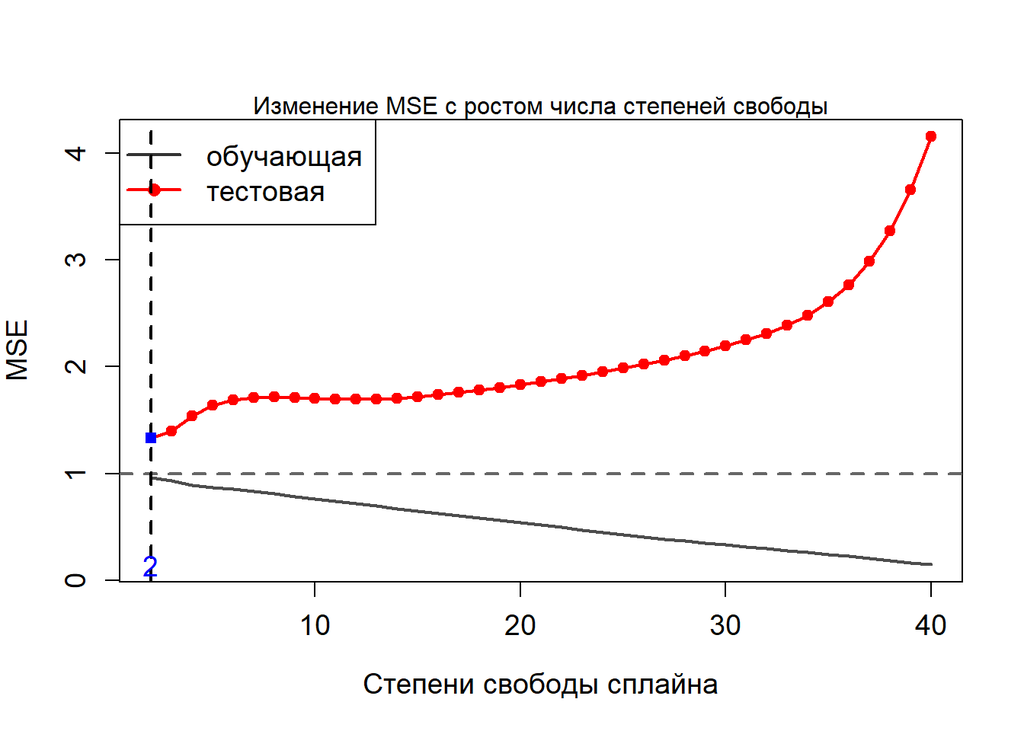

```r
#  График 2: Зависимость MSE от гибкости модели ################################

plot(x = tbl$df, y = tbl$MSE.test,
     type = 'l', col = 'red', lwd = 2,
     xlab = 'Степени свободы сплайна', ylab = 'MSE',
     ylim = c(min(tbl$MSE.train, tbl$MSE.test),
              max(tbl$MSE.train, tbl$MSE.test)),
     cex = 1.2, cex.lab = 1.2, cex.axis = 1.2)

# заголовок
mtext('Изменение MSE с ростом числа степеней свободы', side = 3)

points(x = tbl$df, y = tbl$MSE.test,
       pch = 21, col = 'red', bg = 'red')
lines(x = tbl$df, y = tbl$MSE.train, col = grey(0.3), lwd = 2)
# неустранимая ошибка
abline(h = res.sd, lty = 2, col = grey(0.4), lwd = 2)

# легенда
legend('topleft', legend = c('обучающая', 'тестовая'),
       pch = c(NA, 16),
       col = c(grey(0.2), 'red'),
       lty = c(1, 1), lwd = c(2, 2), cex = 1.2)

# степени свободы у наименьшей ошибки на тестовой выборке
min.MSE.test <- min(tbl$MSE.test)
df.min.MSE.test <- tbl[tbl$MSE.test == min.MSE.test, 'df']

# компромисс между точностью и простотой модели по графику
df.my.MSE.test <- 2
my.MSE.test <- tbl[tbl$df == df.my.MSE.test, 'MSE.test']

# ставим точку на графике
abline(v = df.my.MSE.test,
       lty = 2, lwd = 2)
points(x = df.my.MSE.test, y = my.MSE.test,
       pch = 15, col = 'blue')
mtext(df.my.MSE.test,
      side = 1, line = -1, at = df.my.MSE.test, col = 'blue', cex = 1.2)
```